# Stochastic Process Linear Death and Linear Growth

Daniel Nzambuli

2024-03-17

# Question 1

Suppose you are tasked with analyzing a Yule Furry process, denoted as {X(t),t ≥ 0}, within the R Studio environment. The process is characterized by a birth rate (λ), where X(0) = a = 5 represents the initial population size.

## 1. Calculate the mean function and variance function of the Yule Furry process.

The model is mostly a growth model this means that

$$mean\ function = E X(t) = a * e ^{(\lambda -\mu)t}\\
variance\ function = \sigma ^2(t) = DX(t) = \frac{a(\lambda +
\mu)}{\lambda - \mu} e^{(\lambda - \mu)t} \left( e^{(\lambda - \mu)t} -
1\right)$$

in this case $\mu = 0$

```r
a = 5

mean_func = function(lambda, t){
  return (a * exp(lambda * t))
}

var_func = function(lambda, t){
  sec1 = a
  sec2 = exp(t * lambda)
  sec3 = exp(t * lambda )
  return (sec1 * sec2 * (sec3 - 1))
}
```

## 2. For a specified time (t = 7 units), with birth rates λ = 0.2 and λ = 0.3:

### a.) Determine the expected value E(X(7)).

```r
q1_birth_rate = data.frame(expected_t7= c(mean_func(0.2, 7), mean_func(0.3, 7)))
rownames(q1_birth_rate) = c("lambda 0.2", "lambda 0.3")

q1_birth_rate
```

```
##            expected_t7
## lambda 0.2    20.27600
## lambda 0.3    40.83085
```

### b.) Compute the variance Var(X(7)).

```r
q1_birth_rate$var_t7 = c(var_func(0.2, 7), var_func(0.3, 7))
q1_birth_rate
```

```
##            expected_t7    var_t7
## lambda 0.2    20.27600  61.94723
## lambda 0.3    40.83085 292.60081
```

### c.) Calculate the probability P[X(7) = 20].

The probability of the birth process to give 20 individuals at time $t = 7\ units$ we need to simulate a growth progression using a negative binomial distribution expressed as

$$P(X = 20) = _{k + r-1}C_k * (1-p) ^{r} * p^{k}$$

> **Where**
> - **K** number of failures of the growth resulting in 20 individuals by t= 7
> - **R** number of successes
> - **p** probability of success of a given trial

because the mean of the population is expressed as $a * e ^{\lambda * t}$ to model the population growth the requirements are

> - every person gives birth at a rate of $\lambda$ which is completely independent of the other people in the population
> - The probability of more than one birth over a small period of time $\Delta t$ `should be negligible` . A person can only give birth to 1 other person at any time change.
> - The growth follows an exponential growth with a probability of $\lambda$

> **Because of this** birth follows a poison process characteristics where events occur independently and at a constant rate

using the negative binomial equation

$$p[x(7) = k] ={k - 1\choose k - a} * e^{-a * \lambda t} * \left(1
-e^{-\lambda t}\right)^{k -a}$$

> **where**
> - **K** = 20
> - **a** = 5

```r
calc_prob_20 = function(k, a, lambda, t){
  choice = choose((k -1), (k-a))
  first_e = -a * lambda * t
  second_e = -lambda * t

  calc = choice * exp(first_e) * (1-exp(second_e))^(k-a)
  return(calc)
}
```

#### solution for lambda 0.2

```r
cat("The P[x(7) = 20] for lambda = 0.2 is: ", calc_prob_20(k= 20, a= 5, lambda=0.2, t=7), "\n")
```

```
## The P[x(7) = 20] for lambda = 0.2 is:  0.05055136
```

```r
cat("The P[x(7) = 20] for lambda = 0.3 is: ", calc_prob_20(k= 20, a= 5, lambda=0.3, t=7), "\n")
```

```
## The P[x(7) = 20] for lambda = 0.3 is:  0.01504257
```

## 3. Generate 300 realizations of the Yule Furry process observed for a duration of T time units. Verify whether X(T) follows a geometric distribution through graphical analysis and appropriate

statistical test procedures. Given Parameters:

> - Initial population size (a) = 5
> - Time value (T) = 7 units
> - Birth rates (λ) = 0.2, 0.3
> - Number of realizations = 300

```r
# use the mean value for each realization
# mean value is from mean_func()
simulate_q1 = function(mean, realizations){
  return(rpois(realizations, mean))
}
```

```r
# simulating for lambda 0.2
simulations = 300

lambda_0.2 = simulate_q1(mean_func(0.2, 7), simulations)
sim_data = data.frame(lambda_0.2)
sim_data
```

```
##     lambda_0.2
## 1           12
## 2           20
## 3           18
## 4           20
## 5           21
## 6           24
## 7           22
## 8           25
## 9           16
## 10          27
## 11          24
## 12          17
## 13          13
## 14          15
```

[output cut: 286 more lines]

```r
# simulate for lambda 0.3
sim_data$lambda_0.3 = simulate_q1(mean_func(0.3, 7), simulations)
sim_data
```

```
##     lambda_0.2 lambda_0.3
## 1           12         24
## 2           20         49
## 3           18         43
## 4           20         44
## 5           21         39
## 6           24         45
## 7           22         37
## 8           25         53
## 9           16         39
## 10          27         34
## 11          24         33
## 12          17         44
## 13          13         28
## 14          15         31
```

[output cut: 286 more lines]

### a.) Assessing Statistically

> - create the vector of the values generated by each lambda value
> - Estimate the parameter of the geometric progression

> $$parameter = \frac{1}{mean(vector)}$$
> - Perform the Kolmogorov-Smirnov (k-s) test to compare the empirical data to geometric data

```r
stat_test = function(data ){
  p_estimate = 1/ mean(data)
  test = ks.test(data, "pgeom", p_estimate)
  return(test)
}
```

```r
stat_test(sim_data$lambda_0.2)
```

```
##
##  Asymptotic one-sample Kolmogorov-Smirnov test
##
## data:  data
## D = 0.47883, p-value < 2.2e-16
## alternative hypothesis: two-sided
```

```r
stat_test(sim_data$lambda_0.3)
```

```
##
##  Asymptotic one-sample Kolmogorov-Smirnov test
##
## data:  data
## D = 0.52361, p-value < 2.2e-16
## alternative hypothesis: two-sided
```

> **Interpretation**

> Given that the `Kolmogorov-Smirnov test` $h_0$ is that there is no statistically significant difference in the distribution of the generated data and the distribution of a geometric distribution
> - Given that the p-value of both the data generated from $\lambda = 0.2 || \lambda = 0.3$ is $<2.2e-16$
> - The null hypothesis is `rejected` . This indicates that there is a statistically significant difference in the distribution of the generated data and a geometric progression data.

### b.) Graphical test

```r
max.min = function(data){
  print(cat("The minimum value is:", min(data), "\nThe max value is:", max(data), "\n"))
}
```

```r
max.min(sim_data$lambda_0.2)
```

```
## The minimum value is: 8
## The max value is: 38
## NULL
```

```r
max.min(sim_data$lambda_0.3)
```

```
## The minimum value is: 21
## The max value is: 60
## NULL
```

### Sample geometric Graph

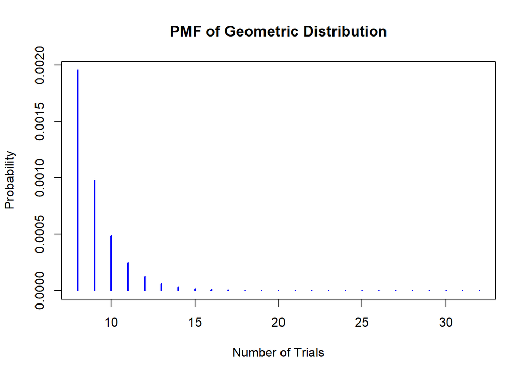

```r
p = 0.5
x_val = seq(8, 32)
samp = dgeom(x_val, p)

plot(x_val, samp, type = 'h', lwd = 2, col = 'blue',
     main = 'PMF of Geometric Distribution',
     xlab = 'Number of Trials', ylab = 'Probability')
```

```r
actual_data_plot = function(data){
  # Assuming 'data' contains the observed values
  plot(data, log = "y", type = "o", main = "Log-Plot of the Data",
     xlab = "Observation index", ylab = "Log of value")

}
```

### actual data for lambda = 0.2

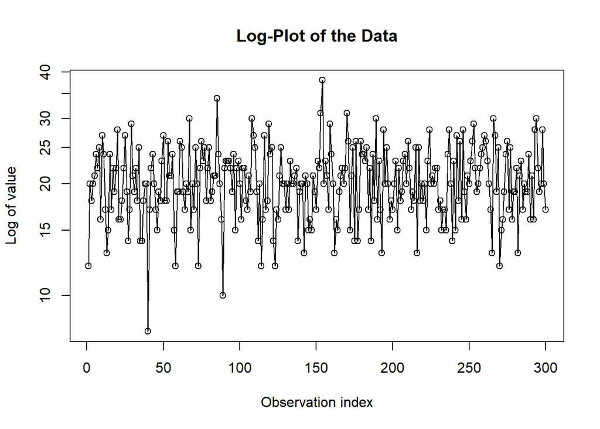

```r
data1.1 = sim_data$lambda_0.2
actual_data_plot(data1.1)
```

> **Interpretation**

> The data generated by $\lambda = 0.2$ does not follow a geometric progression as the plot is just a wave with sharp edges across the x axis.

### actual values from lambda = 0.3

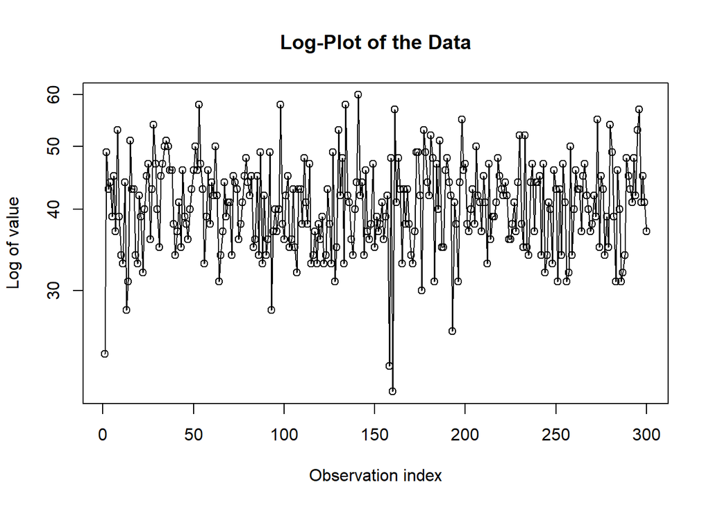

```r
data2.1 = sim_data$lambda_0.3
actual_data_plot(data2.1)
```

> The data from $\lambda = 0.3$ also doesn’t follow a geometric progression.

# Question 2

Consider a population with an initial count of individuals, denoted as (a = 6), at time (t = 0). The lifespan of each individual follows an exponential distribution with parameter (µ). Suppose (X(t)) represents the count of survivors in this population at time (t), and the evolution of (X(t)) over time (t) is modeled as a linear death process with a death rate of (µ).

## i. Compute the mean function and variance function of the linear death process.

```r
mean_death = function(a, mu, t){
  return(a * exp(-mu * t))
}
var_death = function(a , mu, t){
  return(a * exp(-mu * t) * (1 - exp(-mu*t) ))
}
```

## ii. For given death rates (µ = 0.3) and (µ = 0.4), calculate the expected population size and thevariance of the population size at (t = 5). Additionally, determine the probability that at (t = 5), the population size is less than (4.3).

```r
a = 6
mu1 = 0.3
mu2 = 0.4
t.2 = 5
death_data = data.frame(mean = c(mean_death(a, mu1, t.2), mean_death(a, mu2, t.2)),
                        var = c(var_death(a, mu1, t.2), var_death(a, mu2, t.2)))
rownames(death_data) = c(0.3, 0.4)
death_data
```

```
##          mean       var
## 0.3 1.3387810 1.0400586
## 0.4 0.8120117 0.7021179
```

```r
prob_death= function(a,mu, t.2){
 p_survive = exp(-mu * t.2)
 return(pbinom(4.3, a, p_survive))
}
death_data$probability = c(prob_death(6,mu1, 5), prob_death(6,mu2, 5))

death_data
```

```
##          mean       var probability
## 0.3 1.3387810 1.0400586   0.9972985
## 0.4 0.8120117 0.7021179   0.9997583
```

> **Reason**

> for a linear death process with $X(0) = a > 0$ and a death rate $\mu$ . The change in the population $X(t)$ follows a binomial $B(a, e^{-\mu * t})$ distribution

## iii. Further, generate 300 realizations of the linear death process observed for a duration of (T) time units and verify whether (X(T)) follows a binomial distribution through graphical analysis and appropriate statistical test procedures.

```r
set.seed(123)
# remember death follows a binomia process
sim_death = function(a, t.2, mu){
  p_survive = exp(-mu * t.2)
  goal = rbinom(300, a , p_survive)
  return(goal)
}
```

```r
sim_dead = data.frame(mu_0.3 =sim_death(6,5, 0.3),
                      mu_0.4 =sim_death(6,5, 0.4))
sim_dead
```

```
##     mu_0.3 mu_0.4
## 1        1      1
## 2        2      0
## 3        1      1
## 4        3      1
## 5        3      1
## 6        0      1
## 7        1      0
## 8        3      0
## 9        1      1
## 10       1      1
## 11       3      0
## 12       1      1
## 13       2      1
## 14       1      0
```

[output cut: 286 more lines]

### Statistics Test

```r
test_binom <- function(data, mu) {

  total_count=sum(data)
  max_value=max(as.numeric(names(table(data))))
  size=max_value

  observed <- table(data)


  expected_prob <- dbinom(0:size, size, exp(-mu * 5))
  expected_counts <- expected_prob * total_count


  chisq.test(observed, p = expected_prob)
}
```

```r
dead1 = sim_dead$mu_0.3
dead2 = sim_dead$mu_0.4
test_binom(dead1, 0.3)
```

```
##
##  Chi-squared test for given probabilities
##
## data:  observed
## X-squared = 132.71, df = 4, p-value < 2.2e-16
```

```r
test_binom(dead2, 0.4)
```

```
##
##  Chi-squared test for given probabilities
##
## data:  observed
## X-squared = 121.26, df = 4, p-value < 2.2e-16
```

> Given that $h_0$ is that there is no statistically significant difference in the distribution of the generated data and the distribution of a binomial distribution
> - Given that the p-value of both the data generated from $\mu = 0.3 || \mu = 0.4$ is $<2.2e-16$
> - The null hypothesis is `rejected` . This indicates that there is a statistically significant difference in the distribution of the generated data and a binomial progression data.

### Graphical assessment

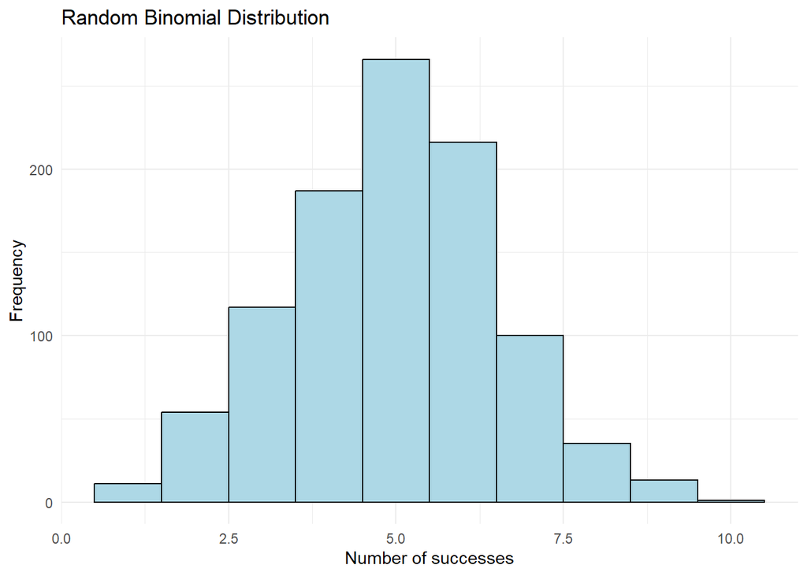

```r
library(ggplot2)


n=10
p=0.5

# Generate random binomial data
data=rbinom(1000, size = n, prob = p)

ggplot(data = data.frame(x = data), aes(x = x)) +
  geom_histogram(binwidth = 1, color = "black", fill = "lightblue") +
  labs(title = "Random Binomial Distribution", x = "Number of successes", y = "Frequency") +
  theme_minimal()
```

### Compare the generated data

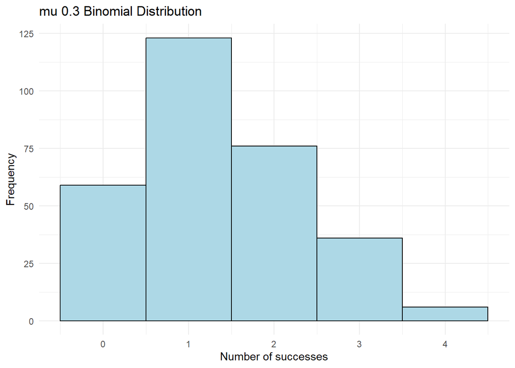

```r
ggplot(data = sim_dead,aes(x= mu_0.3))+
  geom_histogram(binwidth = 1, color = "black", fill = "lightblue") +
  labs(title = "mu 0.3 Binomial Distribution", x = "Number of successes", y = "Frequency") +
  theme_minimal()
```

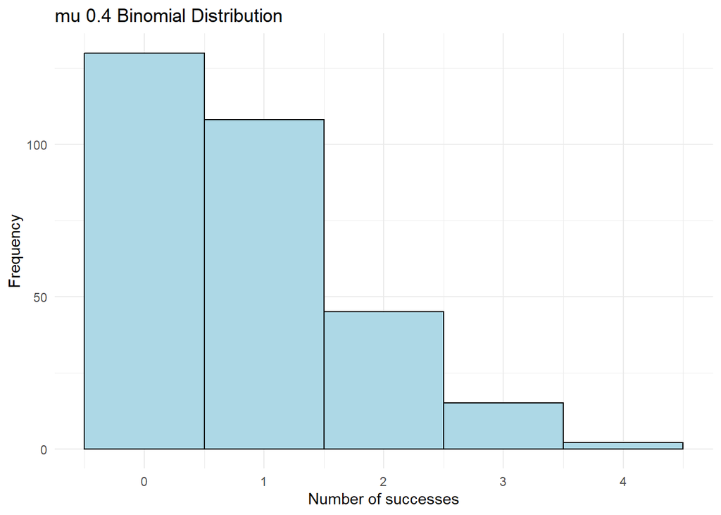

```r
ggplot(data = sim_dead,aes(x= mu_0.4))+
  geom_histogram(binwidth = 1, color = "black", fill = "lightblue") +
  labs(title = "mu 0.4 Binomial Distribution", x = "Number of successes", y = "Frequency") +
  theme_minimal()
```

This tracks with the statistical data.

# Question 3

In this task, you are required to analyze a linear birth-death process using R Studio. The birth and death rates are explicitly assigned, with a given time (t = 30) units. The birth rate (λ) is set to 1.8, and the death rate (µ) is set to 0.7. Initially, the process starts with one entity, (X(0) = 1).

## i. Calculate the mean and variance functions of the process at (t = 5).

check if life is equal to death. **If so**

$$E(x) = a\\
var = 2\lambda t$$

**If not**

$$E(x) = a * e ^{(\lambda - \mu)t}\\
var = \frac{\lambda + \mu }{\lambda - \mu} * e ^{(\lambda -\mu)t} *(e
^{(\lambda -\mu)t} - 1)$$

```r
mu.3 =0.7
lambda.3 = 1.8
t.3 = 5

mu.3 == lambda.3
```

```
## [1] FALSE
```

```r
mean_birth_death = function(a , lambda, mu, t){
  return(a*exp((lambda - mu) * t))
}

var_birth_death = function(a, lambda, mu, t){
  seq1 = (lambda + mu)/ (lambda-mu)
  seq2 = exp((lambda - mu) * t)
  seq3 = exp((lambda - mu) * t) - 1

  return(seq1 * seq2 * seq3)
}
```

```r
a = 1
birth_death = data.frame(mean = mean_birth_death(a, lambda.3, mu.3, t.3), variance = var_birth_death(a, lambda.3, mu.3, t.3))
birth_death
```

```
##       mean variance
## 1 244.6919 135521.5
```

## ii. Determine the probability of absorption into state 0.

probability of extinction is

$$\lambda \leq \mu = 1\\
\lambda \gt \mu = \frac{\mu}{\lambda}$$

```r
if (lambda.3 > mu.3) {
  P_extinction=mu.3 / lambda.3
} else {
  P_extinction=1
}

P_extinction
```

```
## [1] 0.3888889
```

## iii. Calculate the probability of extinction on or before time (t = 5).Given Parameters:

> - Birth Rate (λ): 1.8
> - Death Rate (µ): 0.7
> - Initial State (X(0)): 1
> - Time (t): 30 units

```r
simulate_birth_death=function(X0, lambda, mu, t_target){
  xt = X0
  t = 0
  while (xt > 0 && t <= t_target) {
    rate = lambda * xt + mu * xt # transition rate
    t_step=rexp(1, rate) # transition time
    t=t + t_step
    if (t <= t_target && xt > 0) { # extinction has not happened by time 5
       if (runif(1) < lambda * xt / rate) {
        xt <- xt + 1
       } else {
        xt <- xt - 1
       }

    }
  }
    return(xt == 0) #if extinction doesnt occur return false
}
```

```r
time_5_extinct = sum(replicate(300, simulate_birth_death(1, 1.8, 0.7, 5)))

prob_extinct = time_5_extinct/ 300

cat("The probability of extinction by time 5 units is: ", prob_extinct, "\n")
```

```
## The probability of extinction by time 5 units is:  0.35
```